# Assignment5_JianghongMan

6. Use both models from part 4 and the h-period argument in the forecast() function to forecast each month of 1980 (i.e., Jan, Feb, …, Dec.) Plot the test dataset and forecasted values.

```r
predict_fit1 <- forecast(fit1, h = 12)
predict_fit1
```

```
##          Point Forecast     Lo 80     Hi 80     Lo 95     Hi 95
## Jan 1980       68.25914  52.90792  83.61035  44.78148  91.73679
## Feb 1980       61.91431  42.60975  81.21887  32.39054  91.43808
## Mar 1980       59.21253  37.94477  80.48029  26.68630  91.73876
## Apr 1980       66.09718  43.76727  88.42709  31.94653 100.24783
## May 1980       94.27864  71.35384 117.20344  59.21818 129.33910
## Jun 1980      119.14639  95.88272 142.41005  83.56768 154.72509
## Jul 1980      130.76289 107.30446 154.22131  94.88632 166.63945
## Aug 1980      146.59020 123.01929 170.16111 110.54160 182.63880
## Sep 1980      141.25197 117.61591 164.88803 105.10374 177.40020
## Oct 1980      125.58326 101.90940 149.25711  89.37722 161.78929
## Nov 1980       93.90821  70.21241 117.60401  57.66861 130.14781
## Dec 1980       74.39740  50.68885  98.10594  38.13830 110.65649
```

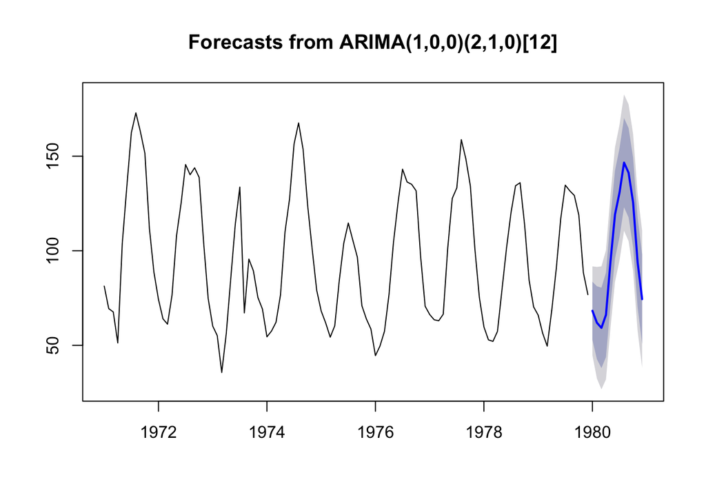

```r
plot(predict_fit1)
```

```r
predict_fit2 <- forecast(fit2, h = 12)
predict_fit2
```

```
##          Point Forecast     Lo 80     Hi 80     Lo 95     Hi 95
## Jan 1980       67.48752  51.27888  83.69615 42.698545  92.27649
## Feb 1980       61.96863  40.87568  83.06158 29.709742  94.22751
## Mar 1980       59.86753  34.82546  84.90960 21.568994  98.16607
## Apr 1980       67.49677  39.04861  95.94493 23.989060 111.00448
## May 1980       95.94793  64.45999 127.43587 47.791275 144.10458
## Jun 1980      121.14990  86.89084 155.40896 68.755190 173.54461
## Jul 1980      133.11741  96.29519 169.93963 76.802683 189.43214
## Aug 1980      148.75470 109.53648 187.97292 88.775611 208.73379
## Sep 1980      143.61167 102.13564 185.08770 80.179552 207.04379
## Oct 1980      128.13923  84.52210 171.75636 61.432590 194.84588
## Nov 1980       96.56940  50.91147 142.22733 26.741624 166.39718
## Dec 1980       77.27367  29.66233 124.88501  4.458415 150.08892
```

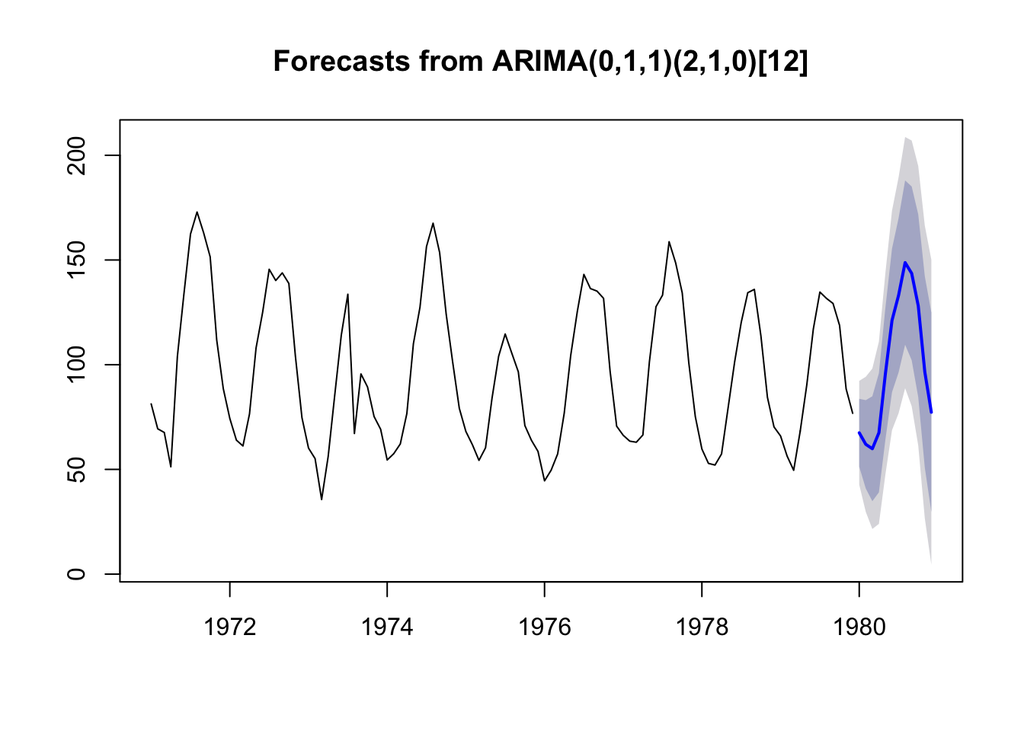

```r
plot(forecast(predict_fit2,h=12))
```

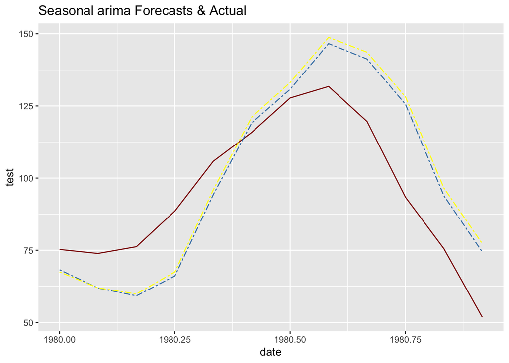

```r
df1 <- data.frame(date=index(test),test=test,predict1=predict_fit1$mean,predict2=predict_fit2$mean)

p1<- ggplot(df1, aes(x=date)) +
  geom_line(aes(y = test), color = "darkred") +
  geom_line(aes(y = predict1), color="steelblue", linetype="twodash") +
  geom_line(aes(y = predict2), color="yellow", linetype="twodash") +
  ggtitle('Seasonal arima Forecasts & Actual')

p1
```

7. Compare the forecast with the actual test data by calculating the Mean Absolute Percentage Error (MAPE) and Mean Squared Error (MSE). Which model is better to forecast the Manufacturer’s Stocks for each month of 1980 (i.e., Jan, Feb, …, Dec)?

```r
MAPE <- MAPE(predict_fit1$mean, test)
MAPE2 <- MAPE(predict_fit2$mean, test)
MSE <- MSE(predict_fit1$mean, test)
MSE2 <- MSE(predict_fit2$mean, test)
Eval <- cbind(c(MAPE, MAPE2), c(MSE, MSE2))
colnames(Eval) <- c('MAPE', 'MSE')
rownames(Eval) <- c('d=0', 'd=1')
Eval
```

```
##          MAPE      MSE
## d=0 0.1842871 309.5345
## d=1 0.1975673 352.8060
```

8. Forecast each month of 1980 (i.e., Jan, Feb, …, Dec.) using the seasonal naïve forecast method. Plot the test dataset and forecasted values, and compare the forecast with the actual test data by calculating the Mean Absolute Percentage Error (MAPE) and Mean Squared Error (MSE).

```r
fit_SNaive <- snaive(train)
predict_fit_SNaive <- forecast(fit_SNaive, h=12)
predict_fit_SNaive
```

```
##          Point Forecast     Lo 80     Hi 80     Lo 95    Hi 95
## Jan 1980          65.96  32.64587  99.27413 15.010431 116.9096
## Feb 1980          56.36  23.04587  89.67413  5.410431 107.3096
## Mar 1980          49.57  16.25587  82.88413 -1.379569 100.5196
## Apr 1980          68.33  35.01587 101.64413 17.380431 119.2796
## May 1980          90.32  57.00587 123.63413 39.370431 141.2696
## Jun 1980         117.06  83.74587 150.37413 66.110431 168.0096
## Jul 1980         134.69 101.37587 168.00413 83.740431 185.6396
## Aug 1980         131.67  98.35587 164.98413 80.720431 182.6196
## Sep 1980         129.25  95.93587 162.56413 78.300431 180.1996
## Oct 1980         118.77  85.45587 152.08413 67.820431 169.7196
## Nov 1980          88.44  55.12587 121.75413 37.490431 139.3896
## Dec 1980          76.79  43.47587 110.10413 25.840431 127.7396
```

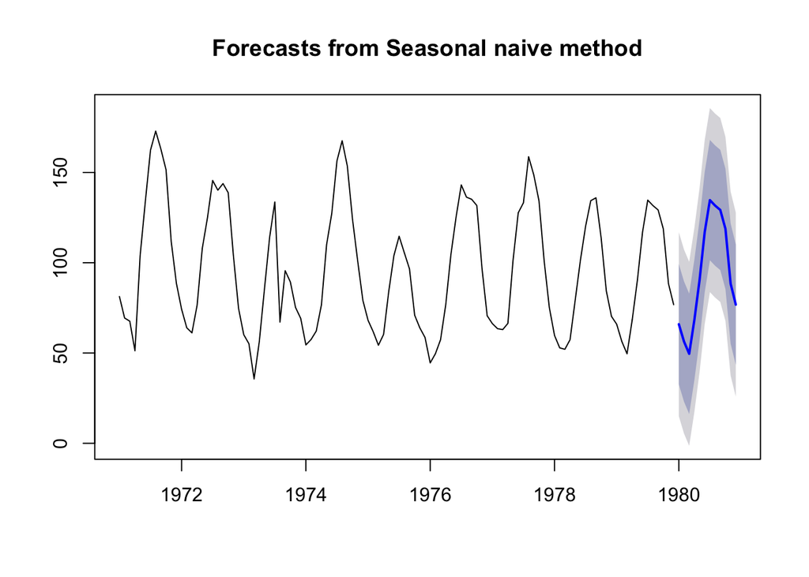

```r
plot(predict_fit_SNaive)
```

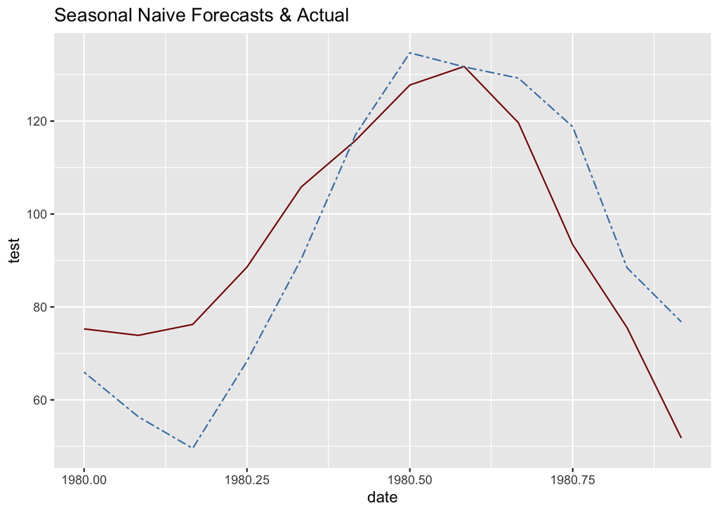

```r
df3 <- data.frame(date=index(test),test=test,predicts=predict_fit_SNaive$mean)

p3 <- ggplot(df3, aes(x=date)) +
  geom_line(aes(y = test), color = "darkred") +
  geom_line(aes(y = predicts), color="steelblue", linetype="twodash") +
  ggtitle('Seasonal Naive Forecasts & Actual')

p3 +theme(legend.position="bottom")
```

```r
MAPE3 <- MAPE(predict_fit_SNaive$mean, test)
MSE3 <- MSE(predict_fit_SNaive$mean, test)
Eval2 <- rbind(Eval, c(MAPE3, MSE3))
rownames(Eval2) <- c('d=0', 'd=1','snaive')
Eval2
```

```
##             MAPE      MSE
## d=0    0.1842871 309.5345
## d=1    0.1975673 352.8060
## snaive 0.1797548 277.8286
```

The seasonal naïve forecast method has the lowest MAPE & MSE score. Thus, the snaive model is the best to forecast the Manufacturer’s Stocks for each month of 1980.